# ASSIGNMENT 2 FML ESWAR DUMPA

Eswar Dumpa

2024-02-25

#Overview

#Questions - Responses

   True positive = 121 True Negative = 1811 False Positive = 7 False Negative = 61

4.Classify the customer using the best k? A. Based on the best value of K, which is K=3, the client would be categorized as 0. Thus, the client declines the personal loan.

5. Repartition the data, this time into training, validation, and test sets (50% : 30% : 20%). Apply the k-NN method with the k chosen above. Compare the confusion matrix of the test set with that of the training and validation sets. Comment on the differences and their reason.

A. Compared to test and validation data sets, the training set has higher accuracy (97.4%), sensitivity (75.93%), and specificity (99.7%). It was caused by a number of things, including sample size, data leaking, and overfitting. The primary cause was overfitting, which occurs when a model is given permission to commit training data to memory in order to capture all of the training data’s headlines. Consequently, the model’s performance on training data will be remarkably higher than that of the other two data sets.

For Testing data: Accuracy was 95.60% Sensitivity was 60.64% Specificity was 99.23%

For Validation data: Accuracy was 96.13% Sensitivity was 65.51% Specificity was 99.41%

For Training data: Accuracy was 97.44% Sensitivity was 75.93% Specificity was 99.73%

# loaded the required libraries

```r
library(class)
library(caret)
```

```r
library(e1071)
library(ggplot2)
library(lattice)
```

```r
#Data import
universal_bank <- read.csv("C:/Users/eshwa/Documents/Fundamentals of Machine Learning/Assignment 2/UniversalBank.csv")
dim(universal_bank)
```

```
## [1] 5000   14
```

```r
# t function creates the transpose of the dataframe
t(t(names(universal_bank)))
```

```
##       [,1]
##  [1,] "ID"
##  [2,] "Age"
##  [3,] "Experience"
##  [4,] "Income"
##  [5,] "ZIP.Code"
##  [6,] "Family"
##  [7,] "CCAvg"
##  [8,] "Education"
##  [9,] "Mortgage"
## [10,] "Personal.Loan"
## [11,] "Securities.Account"
## [12,] "CD.Account"
## [13,] "Online"
## [14,] "CreditCard"
```

#PUT ID AND ZIP

```r
#here 1 and 5 are the indexes for the columns ID and ZIP
universal_bank <- universal_bank[,-c(1,5)]
dim(universal_bank)
```

```
## [1] 5000   12
```

```r
#education only need to be converted into factor
universal_bank$Education <- as.factor(universal_bank$Education)

# converting education level to dummy variables
groups <- dummyVars(~.,data=universal_bank)
universal_B_bank <- as.data.frame(predict(groups,universal_bank))
```

```r
#gives us same sample if we return the code
set.seed(159)

#60% training data
train_index <- sample(row.names(universal_B_bank), 0.6*dim(universal_B_bank)[1])
train_bank <- universal_B_bank[train_index,]

#40% validation data
valid_index <- setdiff(row.names(universal_B_bank), train_index)
valid_bank <- universal_B_bank[valid_index,]

# Prints the dims of the datasets
cat("Training data dimensions:", dim(train_bank), "\n")
```

```
## Training data dimensions: 3000 14
```

```r
cat("Validation data dimensions:", dim(valid_bank), "\n")
```

```
## Validation data dimensions: 2000 14
```

```r
# 10th variable of the data frame is personal loan
train_norm_bank <- train_bank[,-10] # Personal loan is the 10th variable in data frame
valid_norm_bank <- valid_bank[,-10]

norm.values <- preProcess(train_bank[, -10], method=c("center", "scale"))

#Normalization of training dataset and validation dataset
train_norm_bank <- predict(norm.values, train_bank[, -10])
valid_norm_bank <- predict(norm.values, valid_bank[, -10])
```

1. Age = 40, Experience = 10, Income = 84, Family = 2, CCAvg = 2, Education_1 = 0, Education_2 = 1, Education_3 = 0, Mortgage = 0, Securities Account = 0, CD Account = 0, Online = 1, and Credit Card = 1. Perform a k-NN classification with all predictors except ID and ZIP code using k = 1. Remember to transform categorical predictors with more than two categories into dummy variables first. Specify the success class as 1 (loan acceptance), and use the default cutoff value of 0.5. How would this customer be classified?

```r
#creating a new customer input
new_customer <- data.frame(
  Age = 40,
  Experience = 10,
  Income = 84,
  Family = 2,
  CCAvg = 2,
  Education.1 = 0,
  Education.2 = 1,
  Education.3 = 0,
  Mortgage = 0,
  Securities.Account = 0,
  CD.Account = 0,
  Online = 1,
  CreditCard = 1
)

# Normalizing
new_cust_norm <- new_customer
new_cust_norm <- predict(norm.values, new_cust_norm)
```

```r
#Assuming k=1
knn.pred1 <- class::knn(train = train_norm_bank,
                       test = new_cust_norm,
                       cl = train_bank$Personal.Loan, k = 1)

# Prints knn prediction
knn.pred1
```

```
## [1] 0
## Levels: 0 1
```

#loan not granted for given test dataset for k=1

2. What is a choice of k that balances between over fitting and ignoring the predictor information?

```r
#set range of k 1 to 20
accuracy_bank <- data.frame(k = seq(1, 20, 1), overallaccuracy = rep(0, 20))

for(i in 1:20) {
knn.pred <- class::knn(train = train_norm_bank,
                       test = valid_norm_bank,
                       cl = train_bank$Personal.Loan, k = i)


accuracy_bank[i, 2] <- confusionMatrix(knn.pred, as.factor(valid_bank$Personal.Loan),
                                       positive = "1")$overall[1]
}

#k value with max accuracy
bestValueofk <- which(accuracy_bank[,2] == max(accuracy_bank[,2])) # gives the k value with maximum accuracy
accuracy_bank
```

```
##     k overallaccuracy
## 1   1          0.9620
## 2   2          0.9630
## 3   3          0.9660
## 4   4          0.9615
## 5   5          0.9630
## 6   6          0.9600
## 7   7          0.9630
## 8   8          0.9630
## 9   9          0.9600
## 10 10          0.9575
## 11 11          0.9570
## 12 12          0.9540
## 13 13          0.9535
## 14 14          0.9525
## 15 15          0.9510
## 16 16          0.9500
## 17 17          0.9495
## 18 18          0.9465
## 19 19          0.9465
## 20 20          0.9460
```

```r
#prints the best value of k
cat("The Best Value of k is:", bestValueofk)
```

```
## The Best Value of k is: 3
```

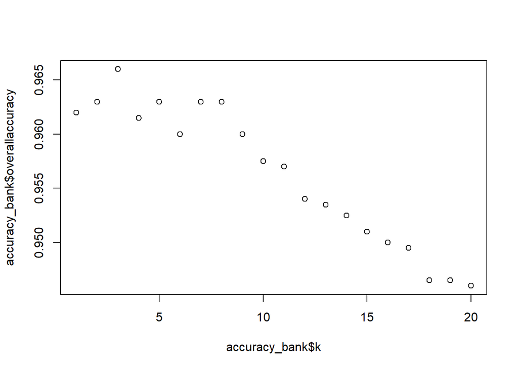

```r
# The Best Value of k is 3
#Plotting graph between k value and accuracy
plot(accuracy_bank$k,accuracy_bank$overallaccuracy)
```

3. Show the confusion matrix for the validation data that results from using the best k.

```r
# take the best k value for prediction
knn.pred2 <- class::knn(train = train_norm_bank,
                        test = valid_norm_bank,
                        cl = train_bank$Personal.Loan, k = bestValueofk)


# confusion matrix for dataset
confusion_matrix <- confusionMatrix(knn.pred2,
                                    as.factor(valid_bank$Personal.Loan), positive = "1")

cat("Confusion Matrix for validation data:", "\n")
```

```
## Confusion Matrix for validation data:
```

```r
# Confusion Matrix of validation data
print(confusion_matrix)
```

```
## Confusion Matrix and Statistics
##
##           Reference
## Prediction    0    1
##          0 1811   61
##          1    7  121
##
##                Accuracy : 0.966
##                  95% CI : (0.9571, 0.9735)
##     No Information Rate : 0.909
##     P-Value [Acc > NIR] : < 2e-16
##
##                   Kappa : 0.7628
##
##  Mcnemar's Test P-Value : 1.3e-10
##
##             Sensitivity : 0.6648
##             Specificity : 0.9961
##          Pos Pred Value : 0.9453
##          Neg Pred Value : 0.9674
##              Prevalence : 0.0910
##          Detection Rate : 0.0605
##    Detection Prevalence : 0.0640
##       Balanced Accuracy : 0.8305
##
##        'Positive' Class : 1
##
```

4. Consider the following customer: Age = 40, Experience = 10, Income = 84, Family = 2, CCAvg = 2, Education_1 = 0, Education_2 = 1, Education_3 = 0, Mortgage = 0, Securities Account = 0, CD Account = 0, Online = 1 and Credit Card = 1. Classify the customer using the best k.

```r
new_customer1 <- data.frame(
  Age = 40,
  Experience = 10,
  Income = 84,
  Family = 2,
  CCAvg = 2,
  Education.1 = 0,
  Education.2 = 1,
  Education.3 = 0,
  Mortgage = 0,
  Securities.Account = 0,
  CD.Account = 0,
  Online = 1,
  CreditCard = 1
)

# Normalizing new customer
new_cust_norm1 <- new_customer1
new_cust_norm1 <- predict(norm.values, new_cust_norm1)
```

```r
knn.pred3 <- class::knn(train = train_norm_bank,
                        test = new_cust_norm1,
                        cl = train_bank$Personal.Loan, k = bestValueofk)

#prints prediction
knn.pred3
```

```
## [1] 0
## Levels: 0 1
```

5. Repartition the data, this time into training, validation, and test sets (50% : 30% : 20%). Apply the k-NN method with the k chosen above. Compare the confusion matrix of the test set with that of the training and validation sets. Comment on the differences and their reason.

```r
set.seed(159) # Ensures that we get the same sample if we rerun the code

# Split the data to training (50%), validation (30%) and testing (20%) sets each
train_index1 <- sample(row.names(universal_B_bank), 0.5*dim(universal_B_bank)[1])
valid_index1 <- sample(setdiff(row.names(universal_B_bank), train_index1),
                       0.3*dim(universal_B_bank)[1])
test_index1 <- setdiff(row.names(universal_B_bank), c(train_index1,valid_index1))

train_Data1 <- universal_B_bank[train_index1,]
valid_Data1 <- universal_B_bank[valid_index1,]
test_Data1 <- universal_B_bank[test_index1,]

# Print dimensions of split datasets
cat("Training data dimensions:", dim(train_Data1), "\n")
```

```
## Training data dimensions: 2500 14
```

```r
cat("Validation data dimensions:", dim(valid_Data1), "\n")
```

```
## Validation data dimensions: 1500 14
```

```r
cat("Testing data dimensions:", dim(test_Data1), "\n")
```

```
## Testing data dimensions: 1000 14
```

```r
#Normalize data for 3 sets
train_norm_bank1 <- train_Data1[ ,-10] #removing the 10th variable(personal loan)
valid_norm_bank1 <- valid_Data1[ ,-10]
test_norm_bank1 <- test_Data1[ ,-10]

#Preprocessing
norm.values1 <- preProcess(train_Data1[ ,-10], method=c("center", "scale"))
train_norm_bank1 <- predict(norm.values1, train_Data1[ ,-10])
valid_norm_bank1 <- predict(norm.values1, valid_Data1[ ,-10])
test_norm_bank1 <- predict(norm.values1, test_Data1[ ,-10])
```

```r
#knn prediction for best value of k
knn.pred.train <- class::knn(train = train_norm_bank1,
                             test = train_norm_bank1,
                             cl = train_Data1$Personal.Loan, k = 3)

#confusion matrix of training data
confusion_matrix.train <- confusionMatrix(knn.pred.train,
                                          as.factor(train_Data1$Personal.Loan), positive = "1")

#print matrix
cat("Confusion Matrix for training data:", "\n")
```

```
## Confusion Matrix for training data:
```

```r
#Confusion Matrix of training data:
print(confusion_matrix.train)
```

```
## Confusion Matrix and Statistics
##
##           Reference
## Prediction    0    1
##          0 2253   58
##          1    6  183
##
##                Accuracy : 0.9744
##                  95% CI : (0.9674, 0.9802)
##     No Information Rate : 0.9036
##     P-Value [Acc > NIR] : < 2.2e-16
##
##                   Kappa : 0.8374
##
##  Mcnemar's Test P-Value : 1.83e-10
##
##             Sensitivity : 0.7593
##             Specificity : 0.9973
##          Pos Pred Value : 0.9683
##          Neg Pred Value : 0.9749
##              Prevalence : 0.0964
##          Detection Rate : 0.0732
##    Detection Prevalence : 0.0756
##       Balanced Accuracy : 0.8783
##
##        'Positive' Class : 1
##
```

```r
knn.pred.valid <- class::knn(train = train_norm_bank1,
                             test = valid_norm_bank1,
                             cl = train_Data1$Personal.Loan, k = bestValueofk)

#confusion matrix
confusion_matrix.valid <- confusionMatrix(knn.pred.valid,
                                          as.factor(valid_Data1$Personal.Loan), positive = "1")

#print matrix
cat("Confusion Matrix for Validation data:", "\n")
```

```
## Confusion Matrix for Validation data:
```

```r
#Confusion Matrix
print(confusion_matrix.valid)
```

```
## Confusion Matrix and Statistics
##
##           Reference
## Prediction    0    1
##          0 1347   50
##          1    8   95
##
##                Accuracy : 0.9613
##                  95% CI : (0.9503, 0.9705)
##     No Information Rate : 0.9033
##     P-Value [Acc > NIR] : < 2.2e-16
##
##                   Kappa : 0.7457
##
##  Mcnemar's Test P-Value : 7.303e-08
##
##             Sensitivity : 0.65517
##             Specificity : 0.99410
##          Pos Pred Value : 0.92233
##          Neg Pred Value : 0.96421
##              Prevalence : 0.09667
##          Detection Rate : 0.06333
##    Detection Prevalence : 0.06867
##       Balanced Accuracy : 0.82463
##
##        'Positive' Class : 1
##
```

```r
#knn prediction for best value of k
knn.pred.test <- class::knn(train = train_norm_bank1,
                            test = test_norm_bank1,
                            cl = train_Data1$Personal.Loan, k = bestValueofk)

#confusion matrix
confusion_matrix.test <- confusionMatrix(knn.pred.test,
                                        as.factor(test_Data1$Personal.Loan), positive = "1")

#print matrix
cat("Confusion Matrix for Test data:", "\n")
```

```
## Confusion Matrix for Test data:
```

```r
# Confusion Matrix
print(confusion_matrix.test)
```

```
## Confusion Matrix and Statistics
##
##           Reference
## Prediction   0   1
##          0 899  37
##          1   7  57
##
##                Accuracy : 0.956
##                  95% CI : (0.9414, 0.9679)
##     No Information Rate : 0.906
##     P-Value [Acc > NIR] : 1.733e-09
##
##                   Kappa : 0.6986
##
##  Mcnemar's Test P-Value : 1.232e-05
##
##             Sensitivity : 0.6064
##             Specificity : 0.9923
##          Pos Pred Value : 0.8906
##          Neg Pred Value : 0.9605
##              Prevalence : 0.0940
##          Detection Rate : 0.0570
##    Detection Prevalence : 0.0640
##       Balanced Accuracy : 0.7993
##
##        'Positive' Class : 1
##
```